# Sentiment analysis of Folketingstidende, regarding guestworkers in Denmark

Anton Knude Soerensen & Benjamin Lykke Christensen

2026-05-25

## Install Sentida and related packages

Note: When running the next codechunk, RStudio might give a message saying that it is best to restart RStudio. We were unable to do that, but the code was run correctly, and could be used for following codechucnks.

```r
# Install 'rlang' (package necessary for installing Sentida)
#install.packages("rlang")
#packageVersion("rlang")

# Install devtools to allow downloading from GitHub
#if(!require("devtools")) install.packages("devtools")

# Install Sentida
devtools::install_github("Guscode/Sentida")
# Install tidyverse and tidytext for data manipulation and sentence splitting
#install.packages("tidyverse")
#install.packages("tidytext")

# For MAC users: Force R to recognize Danish characters (æ, ø, å)
Sys.setlocale(category = "LC_ALL", locale = "UTF-8")
```

```
## [1] "en_US.UTF-8/UTF-8/en_US.UTF-8/C/en_US.UTF-8/en_US.UTF-8"
```

```r
# Load necessary libraries
library(tidyverse)
library(tidytext)
library(Sentida)
```

## Upload datasets and tokenize the texts

We are working with datasets from 4 years in Folketinget, extracted from Folketinget’s archive ‘Folketingstidende’ (shortened as ‘FT’).

In 1974 there was a change of government, and therefore there are 2 datasets, which we will fuse into 1 dataset.

```r
# Load and fuse all datasets

FT1970 <- read_delim("Data/19701.csv", delim = ";", locale = locale(encoding = "ISO-8859-1")) %>% mutate(Year = 1970)

FT19741 <- read_delim("Data/19741.csv", delim = ";", locale = locale(encoding = "ISO-8859-1")) %>% mutate(Year = 1974)

FT19742 <- read_delim("Data/19742.csv", delim = ";", locale = locale(encoding = "ISO-8859-1")) %>% mutate(Year = 1974)

FT1978 <- read_delim("Data/19781.csv", delim = ";", locale = locale(encoding = "ISO-8859-1")) %>% mutate(Year = 1978)

FT1980 <- read_delim("Data/19801.csv", delim = ";", locale = locale(encoding = "ISO-8859-1")) %>% mutate(Year = 1980)

# Fuse the 2 datasets from 1974 into 1
FT1974 <- bind_rows(FT19741, FT19742)

# Fuse every dataset into one master dataset containing all four years
FT_all_years <- bind_rows(FT1970, FT19741, FT19742, FT1978, FT1980)
```

## Filter keywords and run sentiment (for all years) using Sentida

In the following codechunk, we isolate each cell containing the word ‘gæstearbejd*’, and then isolate each cell containing the word ’fremmedarbejd*’. We then calculate the mean sentiment score for each cell, using Sentida.

```r
# Add danish stopwordlist, so the sentiment is not muddled by too many neutral words

#install.packages("stopwords")
library(stopwords)
stop_pattern <- paste0("\\b(", paste(stopwords("da"), collapse = "|"), ")\\b")
stop_pattern <- str_replace(stop_pattern, "\\|ikke\\|", "|")

# Extract rows for 'gæstearbejd*' and calculate individual scores
gaest_all <- FT_all_years %>%
  filter(str_detect(indhold, regex("gæstearbejd", ignore_case = TRUE))) %>%
  mutate(indhold_clean = str_remove_all(indhold, regex(stop_pattern, ignore_case = TRUE))) %>%
  mutate(sentiment_score = map_dbl(indhold_clean, ~ sentida(.x, output = "mean")))

# Extract rows for 'fremmedarbejd*' and calculate individual scores
fremmed_all <- FT_all_years %>%
  filter(str_detect(indhold, regex("fremmedarbejd", ignore_case = TRUE))) %>%
  mutate(indhold_clean = str_remove_all(indhold, regex(stop_pattern, ignore_case = TRUE))) %>%
  mutate(sentiment_score = map_dbl(indhold_clean, ~ sentida(.x, output = "mean")))
```

## Compare the years (summary tables)

Now that we have calculated the mean sentiment score for each cell, we then combine these and calculate the mean sentiment score for each year, and create summary tables.

```r
# By using group_by(Year), R automatically calculates the mean and counts for each year separately!

gaest_summary <- gaest_all %>%
  group_by(Year) %>%
  summarise(
    Mentions = n(),
    Average_Sentiment = mean(sentiment_score, na.rm = TRUE)
  )

fremmed_summary <- fremmed_all %>%
  group_by(Year) %>%
  summarise(
    Mentions = n(),
    Average_Sentiment = mean(sentiment_score, na.rm = TRUE)
  )

# Combine the two separate summary datasets into one wide dataset
unified_overview <- gaest_summary %>%
  select(Year, Gæstearbejd_Mean = Average_Sentiment) %>%
  inner_join(
    fremmed_summary %>% select(Year, Fremmedarbejd_Mean = Average_Sentiment),
    by = "Year"
  )

view(unified_overview)
```

## Sentiment analysis using Sentida

In the following codechunk, we use ggplot2 to create a bar chart, comparing the mean sentiment scores from each year, to get a tidy overview.

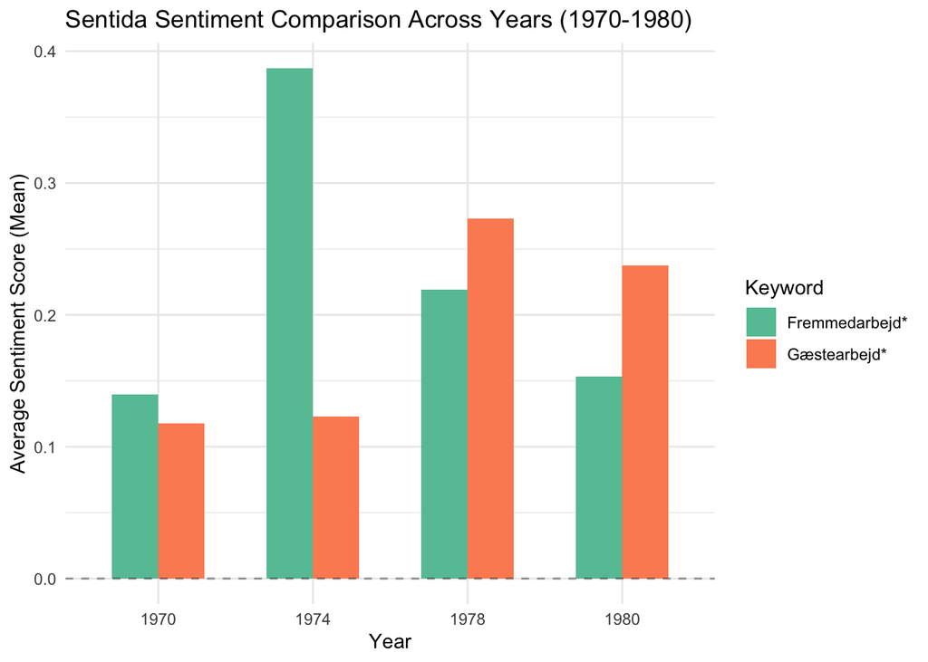

```r
# Combine the summaries to build a clean multi-year plot
plot_data_all <- bind_rows(
  gaest_summary %>% mutate(Keyword = "Gæstearbejd*"),
  fremmed_summary %>% mutate(Keyword = "Fremmedarbejd*")
)

# Generate a side-by-side comparison bar chart for all years
ggplot(plot_data_all, aes(x = factor(Year), y = Average_Sentiment, fill = Keyword)) +
  geom_col(position = "dodge", width = 0.6) +
  geom_hline(yintercept = 0, linetype = "dashed", color = "black", alpha = 0.4) +
  labs(
    title = "Sentida Sentiment Comparison Across Years (1970-1980)",
    x = "Year",
    y = "Average Sentiment Score (Mean)"
  ) +
  theme_minimal() +
  scale_fill_brewer(palette = "Set2")
```

## Sentiment analysis of articles about guestworkers

```r
# Load each of the four articles
# Add a 'Type' column so we can tell them apart once we fuse them
neg_gaest_raw <- read_csv("Data/Article_negative_gaestearbejder.csv", col_names = FALSE) %>%
  rename(sentence = 1) %>%
  mutate(Type = "Negative Gæstearbejder")
pos_gaest_raw <- read_csv("Data/Article_positive_gaestearbejder.csv", col_names = FALSE) %>%
  rename(sentence = 1) %>%
  mutate(Type = "Positive Gæstearbejder")
neg_frem_raw  <- read_csv("Data/Article_negative_fremmedarbejder.csv", col_names = FALSE) %>%
  rename(sentence = 1) %>%
  mutate(Type = "Negative Fremmedarbejder")
pos_frem_raw  <- read_csv("Data/Article_positive_fremmedarbejder.csv", col_names = FALSE) %>%
  rename(sentence = 1) %>%
  mutate(Type = "Positive Fremmedarbejder")

# Combine article datasets into one dataset
articles_combined <- bind_rows(neg_gaest_raw, pos_gaest_raw, neg_frem_raw, pos_frem_raw)

# Run the Sentida sentiment analysis with stopwords added
# This calculates the mean score for each article
articles_sentida_combined <- articles_combined %>%
  mutate(sentence_clean = str_remove_all(sentence, regex(stop_pattern, ignore_case = TRUE))) %>%
  mutate(sentiment_score = map_dbl(sentence_clean, ~ sentida(.x, output = "mean")))

# 4. Create a clean overview of your control scores
articles_sentida_overview <- articles_sentida_combined %>%
  select(Type, sentiment_score)

articles_sentida_overview
```

```
## # A tibble: 4 × 2
##   Type                     sentiment_score
##   <chr>                              <dbl>
## 1 Negative Gæstearbejder            0.0762
## 2 Positive Gæstearbejder            0.565
## 3 Negative Fremmedarbejder          0.136
## 4 Positive Fremmedarbejder          0.739
```

## Find out how often each keyword was used in the dataset

```r
# Count total mentions of each word across the entire dataset
word_counts_by_year <- FT_all_years %>%
  group_by(Year) %>%
  summarise(
    Gaestearbejd_Mentions = sum(str_count(indhold, regex("gæstearbejd", ignore_case = TRUE)), na.rm = TRUE),
    Fremmedarbejd_Mentions = sum(str_count(indhold, regex("fremmedarbejd", ignore_case = TRUE)), na.rm = TRUE)
  )

# Show result
head(word_counts_by_year)
```

```
## # A tibble: 4 × 3
##    Year Gaestearbejd_Mentions Fremmedarbejd_Mentions
##   <dbl>                 <int>                  <int>
## 1  1970                   320                    155
## 2  1974                    27                     36
## 3  1978                    31                     20
## 4  1980                    53                     91
```

Copyright: CC BY 4.0